# EU 2014 Elections: Newspapers EU Evaluations & Reader’s EU Attitudes

Michelle Schimmel

2023-02-02

#### Visualisation Description

This visualisation is based on a survey of Dutch adults and a content analysis of three Dutch newspapers (de Telegraaf, de Volkskrant and NRC Handelsblad). The survey assessed EU attitudes in four waves leading up to the EU election. The content analysis contained the three newspapers’ evaluations of the EU in individual newspaper articles for the total time span.

On this basis, this visualisation set out to uncover the ways in which a newspaper’s EU reporting may affect their readership’s attitudes toward the EU – does more negative evaluations between the survey waves result in more negative EU attitudes (and vice versa)? For this, each outlet’s mean EU evaluation per week was mapped to the mean EU attitudes of their readership as a whole in a given wave. One indicator that an outlets’ EU evaluation affects the attitudes of their readers can be seen for the Volkskrant between December and April. In this time period, the Volkskrants’ published news stories became increasingly negative. At the same time, compared to Volkskrant readers’ EU attitudes in late December, the readers’ attitudes in April became more negative. Conversely, a deviation from this pattern is visible for the Telegraaf: despite more positive EU evaluations in news stories from Mid-February until Mid-March, readership EU attitudes appear to have remained unchanged. The comparison between the news outlets and their readership also shows that the EU evaluation of the Telegraaf generally appears lower than that of the Volkskrant or the NRC Handelsblad. Moreover, the Telegraaf’s readership appears to hold more negative EU attitudes compared to the readerships of the Volkskrant and NRC Handelsblad.

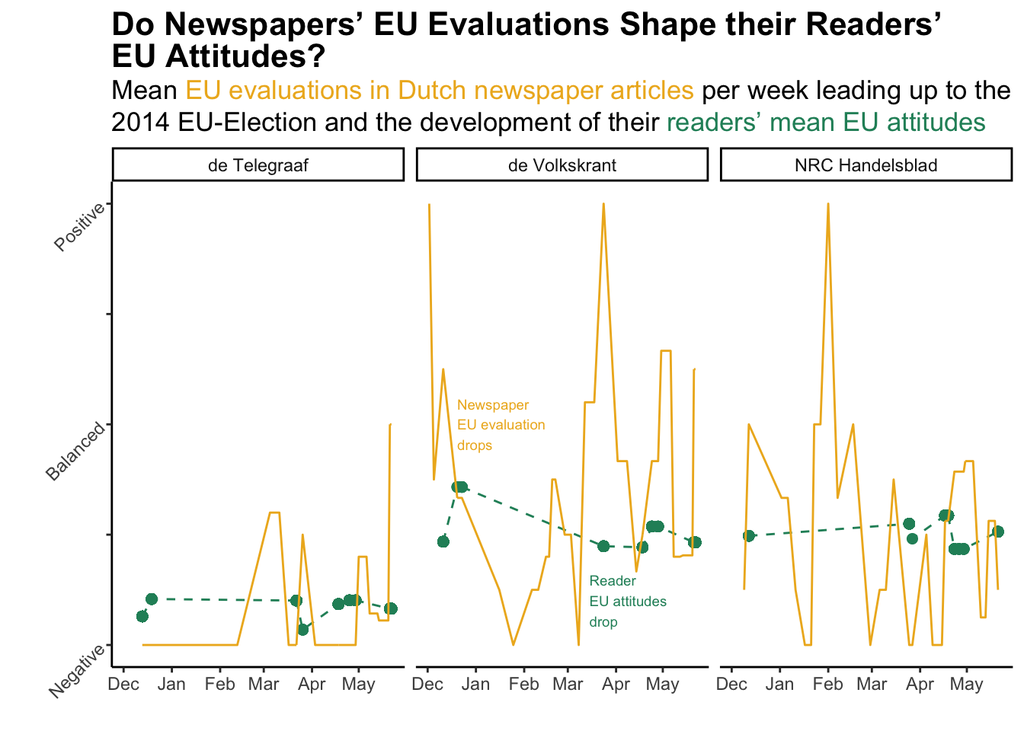